# Peeking into the Black Box

An Actuarial Case Study for Interpretable Machine Learning

Christian Lorentzen & Michael Mayer

2021-04-12

# 1 Introduction

This notebook serves as accompanion to the tutorial [“Peeking into the Black Box”](https://papers.ssrn.com/sol3/papers.cfm?abstract_id=3595944) on [SSRN](https://www.ssrn.com/index.cfm/en/).

The code is similar to the one used in above tutorial and combines the raw R code in the scripts available on [github](https://github.com/JSchelldorfer/ActuarialDataScience/tree/master/8%20-%20Peeking%20into%20the%20Black%20Box) along with some more comments. Please refer to the tutorial for explanations.

Note that the results might vary depending on the R and Python package versions, see last section for the result of `sessionInfo()` and corresponding info on the Python setup.

# 2 Data Preparation

The tutorial uses the French MTPL data set available on [openML (ID 41214)](https://www.openml.org/d/41214).

## 2.1 Load packages and data

```r
library(tidyverse)
library(reshape2)
library(corrplot)
library(splines)
library(splitTools)
library(xgboost)
library(keras)
library(MetricsWeighted)
library(flashlight)

# Fetch data
library(OpenML)
library(farff)

freMTPL2freq <- getOMLDataSet(data.id = 41214)$data
```

## 2.2 Inspect the raw dataset

```r
str(freMTPL2freq)
```

```
## 'data.frame':    678013 obs. of  12 variables:
##  $ IDpol     : num  1 3 5 10 11 13 15 17 18 21 ...
##  $ ClaimNb   : num  1 1 1 1 1 1 1 1 1 1 ...
##  $ Exposure  : num  0.1 0.77 0.75 0.09 0.84 0.52 0.45 0.27 0.71 0.15 ...
##  $ Area      : Factor w/ 6 levels "A","B","C","D",..: 4 4 2 2 2 5 5 3 3 2 ...
##  $ VehPower  : num  5 5 6 7 7 6 6 7 7 7 ...
##  $ VehAge    : num  0 0 2 0 0 2 2 0 0 0 ...
##  $ DrivAge   : num  55 55 52 46 46 38 38 33 33 41 ...
##  $ BonusMalus: num  50 50 50 50 50 50 50 68 68 50 ...
##  $ VehBrand  : Factor w/ 11 levels "B1","B10","B11",..: 4 4 4 4 4 4 4 4 4 4 ...
##  $ VehGas    : chr  "Regular" "Regular" "Diesel" "Diesel" ...
##  $ Density   : num  1217 1217 54 76 76 ...
##  $ Region    : Factor w/ 22 levels "R11","R21","R22",..: 18 18 3 15 15 8 8 20 20 12 ...
```

```r
head(freMTPL2freq, 9)
```

|  | IDpol | ClaimNb | Exposure | Area | VehPower | VehAge | DrivAge | BonusMalus | VehBrand | VehGas | Density | Region |
| --- | --- | --- | --- | --- | --- | --- | --- | --- | --- | --- | --- | --- |
| 0 | 1 | 1 | 0.10 | D | 5 | 0 | 55 | 50 | B12 | Regular | 1217 | R82 |
| 1 | 3 | 1 | 0.77 | D | 5 | 0 | 55 | 50 | B12 | Regular | 1217 | R82 |
| 2 | 5 | 1 | 0.75 | B | 6 | 2 | 52 | 50 | B12 | Diesel | 54 | R22 |
| 3 | 10 | 1 | 0.09 | B | 7 | 0 | 46 | 50 | B12 | Diesel | 76 | R72 |
| 4 | 11 | 1 | 0.84 | B | 7 | 0 | 46 | 50 | B12 | Diesel | 76 | R72 |
| 5 | 13 | 1 | 0.52 | E | 6 | 2 | 38 | 50 | B12 | Regular | 3003 | R31 |
| 6 | 15 | 1 | 0.45 | E | 6 | 2 | 38 | 50 | B12 | Regular | 3003 | R31 |
| 7 | 17 | 1 | 0.27 | C | 7 | 0 | 33 | 68 | B12 | Diesel | 137 | R91 |
| 8 | 18 | 1 | 0.71 | C | 7 | 0 | 33 | 68 | B12 | Diesel | 137 | R91 |

## 2.3 Data preprocessing

Data preprocessing includes a couple of transformations as well as adding a `group_id` identifying rows possibly referring to the same policy. Respecting `group_id` in data splitting techniques (train/test, cross-validation) is essential for honest data validation. Ignoring it is one of the most frequent mistakes in machine learning.

```r
# Grouping id
distinct <- freMTPL2freq %>%
  distinct_at(vars(-c(IDpol, Exposure, ClaimNb))) %>%
  mutate(group_id = row_number())

# Preprocessing
dat <- freMTPL2freq %>%
  left_join(distinct) %>%
  mutate(Exposure = pmin(1, Exposure),
         Freq = pmin(15, ClaimNb / Exposure),
         VehPower = pmin(12, VehPower),
         VehAge = pmin(20, VehAge),
         VehGas = factor(VehGas),
         DrivAge = pmin(85, DrivAge),
         logDensity = log(Density),
         VehBrand = factor(VehBrand, levels =
                             paste0("B", c(12, 1:6, 10, 11, 13, 14))),
         PolicyRegion = relevel(Region, "R24"),
         AreaCode = Area)

# Group sizes of suspected clusters
table(table(dat[, "group_id"]))
```

```
##
##      1      2      3      4      5      6      7      8      9     10     11
## 420102  87628  14516   2535    963    772    723    495    399    283    140
##     12     13     14     15     18     22
##    200      3      1      3      1      1
```

```r
# The worst group (22 times the same)
dat[dat$group_id == 283967, ]
```

|  | IDpol | ClaimNb | Exposure | Area | VehPower | VehAge | DrivAge | BonusMalus | VehBrand | VehGas | Density | Region | group_id | Freq | logDensity | PolicyRegion | AreaCode |
| --- | --- | --- | --- | --- | --- | --- | --- | --- | --- | --- | --- | --- | --- | --- | --- | --- | --- |
| 352236 | 2285383 | 0 | 0.66 | B | 9 | 3 | 35 | 64 | B2 | Regular | 92 | R72 | 283967 | 0 | 4.521789 | R72 | B |
| 352237 | 2285384 | 0 | 0.66 | B | 9 | 3 | 35 | 64 | B2 | Regular | 92 | R72 | 283967 | 0 | 4.521789 | R72 | B |
| 352239 | 2285386 | 0 | 0.66 | B | 9 | 3 | 35 | 64 | B2 | Regular | 92 | R72 | 283967 | 0 | 4.521789 | R72 | B |
| 352240 | 2285387 | 0 | 0.66 | B | 9 | 3 | 35 | 64 | B2 | Regular | 92 | R72 | 283967 | 0 | 4.521789 | R72 | B |
| 352241 | 2285388 | 0 | 0.66 | B | 9 | 3 | 35 | 64 | B2 | Regular | 92 | R72 | 283967 | 0 | 4.521789 | R72 | B |
| 352242 | 2285389 | 0 | 0.66 | B | 9 | 3 | 35 | 64 | B2 | Regular | 92 | R72 | 283967 | 0 | 4.521789 | R72 | B |
| 352243 | 2285390 | 0 | 0.66 | B | 9 | 3 | 35 | 64 | B2 | Regular | 92 | R72 | 283967 | 0 | 4.521789 | R72 | B |
| 352244 | 2285391 | 0 | 0.66 | B | 9 | 3 | 35 | 64 | B2 | Regular | 92 | R72 | 283967 | 0 | 4.521789 | R72 | B |
| 352245 | 2285392 | 0 | 0.66 | B | 9 | 3 | 35 | 64 | B2 | Regular | 92 | R72 | 283967 | 0 | 4.521789 | R72 | B |
| 352246 | 2285393 | 0 | 0.66 | B | 9 | 3 | 35 | 64 | B2 | Regular | 92 | R72 | 283967 | 0 | 4.521789 | R72 | B |

[output cut: 12 more lines]

```r
# Number of observations
nrow(dat)
```

```
## [1] 678013
```

## 2.4 Covariables, Response, Weight

We will define covariables, response and exposure weight variables for later use.

```r
x <- c("VehPower", "VehAge",  "VehBrand", "VehGas", "DrivAge",
       "logDensity", "PolicyRegion")
y <- "Freq"
w <- "Exposure"
```

# 3 Descriptive Analysis

In order to get used to the dataset, we start with a descriptive analysis.

## 3.1 Inspect the prepared dataset

```r
head(dat[, c(x, w, y)])
```

|  | VehPower | VehAge | VehBrand | VehGas | DrivAge | logDensity | PolicyRegion | Exposure | Freq |
| --- | --- | --- | --- | --- | --- | --- | --- | --- | --- |
| 1 | 5 | 0 | B12 | Regular | 55 | 7.104144 | R82 | 0.10 | 10.000000 |
| 2 | 5 | 0 | B12 | Regular | 55 | 7.104144 | R82 | 0.77 | 1.298701 |
| 3 | 6 | 2 | B12 | Diesel | 52 | 3.988984 | R22 | 0.75 | 1.333333 |
| 4 | 7 | 0 | B12 | Diesel | 46 | 4.330733 | R72 | 0.09 | 11.111111 |
| 5 | 7 | 0 | B12 | Diesel | 46 | 4.330733 | R72 | 0.84 | 1.190476 |
| 6 | 6 | 2 | B12 | Regular | 38 | 8.007367 | R31 | 0.52 | 1.923077 |

```r
summary(dat[, c(x, w, y)])
```

```
##     VehPower         VehAge          VehBrand          VehGas
##  Min.   : 4.00   Min.   : 0.000   B12    :166024   Diesel :332136
##  1st Qu.: 5.00   1st Qu.: 2.000   B1     :162736   Regular:345877
##  Median : 6.00   Median : 6.000   B2     :159861
##  Mean   : 6.43   Mean   : 6.976   B3     : 53395
##  3rd Qu.: 7.00   3rd Qu.:11.000   B5     : 34753
##  Max.   :12.00   Max.   :20.000   B6     : 28548
##                                   (Other): 72696
##     DrivAge        logDensity      PolicyRegion       Exposure
##  Min.   :18.00   Min.   : 0.000   R24    :160601   Min.   :0.002732
##  1st Qu.:34.00   1st Qu.: 4.522   R82    : 84752   1st Qu.:0.180000
##  Median :44.00   Median : 5.974   R93    : 79315   Median :0.490000
##  Mean   :45.49   Mean   : 5.982   R11    : 69791   Mean   :0.528545
##  3rd Qu.:55.00   3rd Qu.: 7.413   R53    : 42122   3rd Qu.:0.990000
##  Max.   :85.00   Max.   :10.204   R52    : 38751   Max.   :1.000000
##                                   (Other):202681
##       Freq
##  Min.   : 0.0000
##  1st Qu.: 0.0000
##  Median : 0.0000
##  Mean   : 0.1622
##  3rd Qu.: 0.0000
##  Max.   :15.0000
##
```

## 3.2 Univariate description

How are variables distributed univariately?

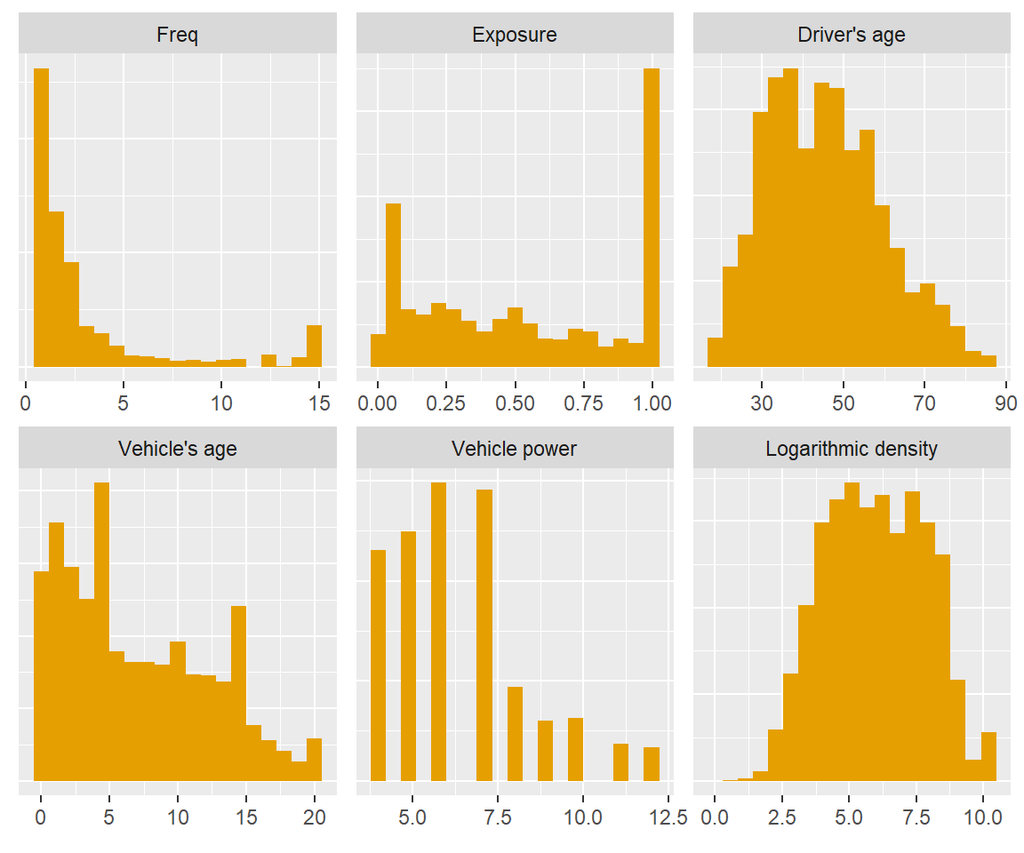

```r
melted <- dat[c("Freq", "Exposure", "DrivAge",
                "VehAge", "VehPower", "logDensity")] %>%
  stack() %>%
  filter(ind != "Freq" | values > 0) %>%
  mutate(ind = fct_recode(
    ind,
    `Driver's age` = "DrivAge",
    `Vehicle's age` = "VehAge",
    `Vehicle power` = "VehPower",
    `Logarithmic density` = "logDensity")
  )

ggplot(melted, aes(x=values)) +
  geom_histogram(bins = 19, fill = "#E69F00") +
  facet_wrap(~ind, scales = "free") +
  labs(x = element_blank(), y = element_blank()) +
  theme(axis.title.y = element_blank(),
        axis.text.y = element_blank(),
        axis.ticks.y = element_blank())
```

## 3.3 Bivariate description

Here, we consider some interesting (but not all) bivariate associations across covariables.

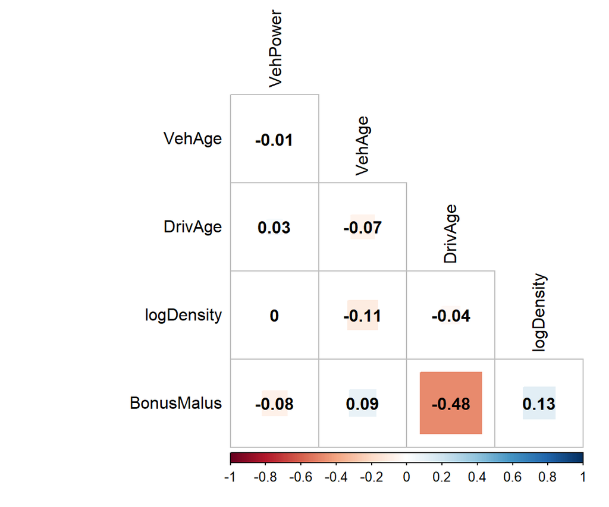

```r
# Correlations across numeric covariables
cor_mat <- dat %>%
  select_at(c(x, "BonusMalus")) %>%
  select_if(is.numeric) %>%
  cor() %>%
  round(2)
corrplot(cor_mat, method = "square", type = "lower", diag = FALSE, title = "",
         addCoef.col = "black", tl.col = "black")
```

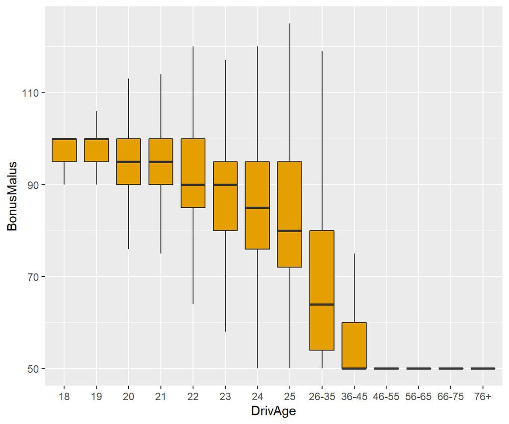

```r
# Boxplots
th <- theme(axis.text.x = element_text(angle = 45, hjust = 1, vjust = 1))

# BonusMalus nach DrivAge
dat %>%
  mutate(DrivAge = cut(DrivAge, c(17:24, seq(25, 85, 10)),
                       labels = c(18:25, "26-35", "36-45", "46-55", "56-65", "66-75", "76+"),
                       include.lowest = TRUE),
         DrivAge = fct_recode(DrivAge)) %>%
ggplot(aes(x = DrivAge, y = BonusMalus)) +
  geom_boxplot(outlier.shape = NA, fill = "#E69F00") +
  coord_cartesian(ylim = c(50, 125))
```

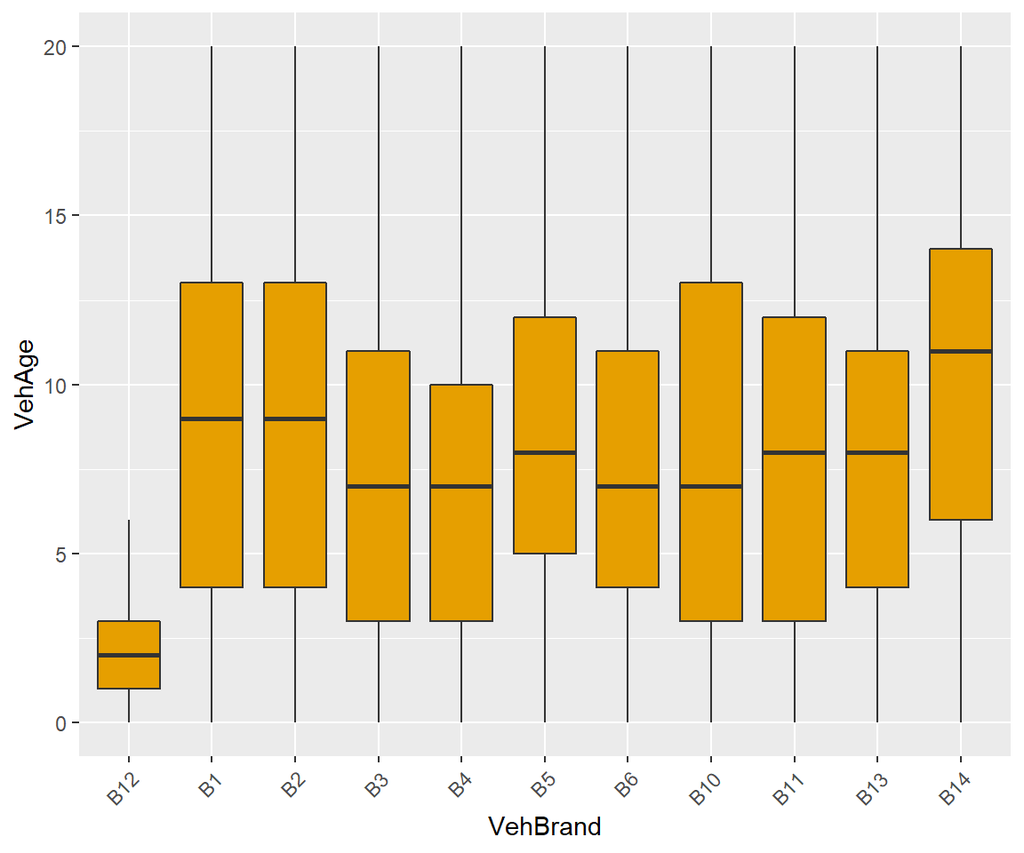

```r
# Brand/vehicle age
dat %>%
  ggplot(aes(x = VehBrand, y = VehAge)) +
  geom_boxplot(outlier.shape = NA, fill = "#E69F00") +
  th
```

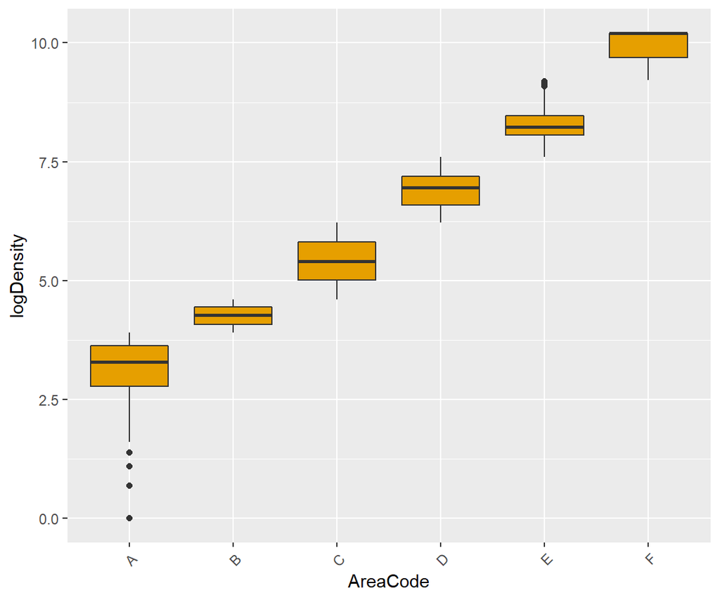

```r
# Density/Area
dat %>%
  ggplot(aes(x = AreaCode, y = logDensity)) +
  geom_boxplot(fill = "#E69F00") +
  th
```

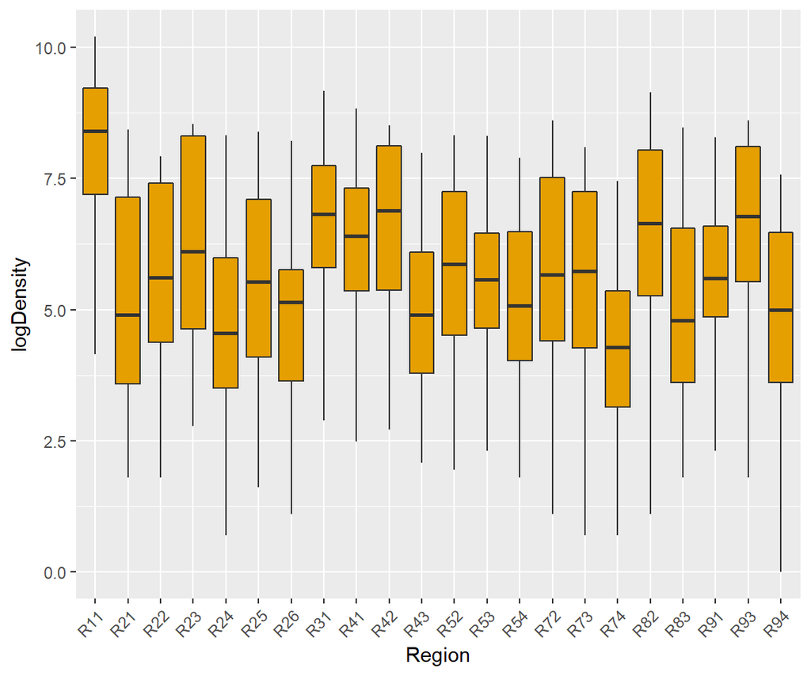

```r
# Density/Region
dat %>%
  ggplot(aes(x = Region, y = logDensity)) +
  geom_boxplot(outlier.shape = NA, fill = "#E69F00") +
  th
```

# 4 Modeling

With the prepared dataset in hand, we are ready for the modeling part.

## 4.1 Grouped split

First, we split the dataset into train and test, keeping together rows with identical `group_id`.

```r
ind <- partition(dat[["group_id"]], p = c(train = 0.8, test = 0.2),
                 seed = 22, type = "grouped")
train <- dat[ind$train, ]
test <- dat[ind$test, ]
```

## 4.2 GLM

Our first model is a generalized linear model without interactions but with a regression spline on two important covariables.

```r
fit_glm <- glm(
  Freq ~ VehPower + ns(VehAge, 5) + VehBrand +
    VehGas + ns(DrivAge, 5) + logDensity + PolicyRegion,
  data = train,
  family = quasipoisson(),
  weights = train[[w]]
)

summary(fit_glm)
```

```
##
## Call:
## glm(formula = Freq ~ VehPower + ns(VehAge, 5) + VehBrand + VehGas +
##     ns(DrivAge, 5) + logDensity + PolicyRegion, family = quasipoisson(),
##     data = train, weights = train[[w]])
##
## Deviance Residuals:
##     Min       1Q   Median       3Q      Max
## -1.1891  -0.3858  -0.2889  -0.1614   5.5028
##
## Coefficients:
##                  Estimate Std. Error t value Pr(>|t|)
## (Intercept)     -0.642967   0.061175 -10.510  < 2e-16 ***
## VehPower         0.010055   0.003819   2.633 0.008468 **
## ns(VehAge, 5)1  -0.651522   0.036795 -17.707  < 2e-16 ***
## ns(VehAge, 5)2  -0.957958   0.040280 -23.782  < 2e-16 ***
## ns(VehAge, 5)3  -0.480952   0.041416 -11.613  < 2e-16 ***
## ns(VehAge, 5)4  -2.623961   0.057378 -45.731  < 2e-16 ***
## ns(VehAge, 5)5  -0.719779   0.050917 -14.136  < 2e-16 ***
## VehBrandB1      -0.133948   0.024057  -5.568 2.58e-08 ***
## VehBrandB2      -0.140218   0.024126  -5.812 6.18e-09 ***
## VehBrandB3      -0.105866   0.030681  -3.451 0.000560 ***
## VehBrandB4      -0.157553   0.041064  -3.837 0.000125 ***
## VehBrandB5      -0.035355   0.035162  -1.005 0.314663
## VehBrandB6      -0.163743   0.039200  -4.177 2.95e-05 ***
## VehBrandB10     -0.137689   0.049472  -2.783 0.005383 **
## VehBrandB11     -0.062418   0.052415  -1.191 0.233715
## VehBrandB13     -0.103539   0.055507  -1.865 0.062135 .
## VehBrandB14     -0.331751   0.105255  -3.152 0.001622 **
## VehGasRegular    0.046127   0.014656   3.147 0.001648 **
## ns(DrivAge, 5)1 -1.143299   0.044577 -25.648  < 2e-16 ***
## ns(DrivAge, 5)2 -0.980883   0.053420 -18.362  < 2e-16 ***
## ns(DrivAge, 5)3 -0.868302   0.043773 -19.837  < 2e-16 ***
## ns(DrivAge, 5)4 -2.395331   0.105288 -22.750  < 2e-16 ***
## ns(DrivAge, 5)5 -0.220119   0.049499  -4.447 8.71e-06 ***
## logDensity       0.066867   0.004518  14.800  < 2e-16 ***
## PolicyRegionR11 -0.089353   0.031071  -2.876 0.004031 **
## PolicyRegionR21 -0.013715   0.112133  -0.122 0.902651
## PolicyRegionR22  0.017811   0.066555   0.268 0.788998
## PolicyRegionR23 -0.123984   0.077393  -1.602 0.109156
```

[output cut: 12 more lines]

```
## PolicyRegionR82  0.003971   0.024922   0.159 0.873419
## PolicyRegionR83 -0.458748   0.104077  -4.408 1.04e-05 ***
## PolicyRegionR91 -0.161941   0.038888  -4.164 3.12e-05 ***
## PolicyRegionR93 -0.075170   0.027400  -2.743 0.006080 **
## PolicyRegionR94  0.112235   0.087395   1.284 0.199060
## ---
## Signif. codes:  0 '***' 0.001 '**' 0.01 '*' 0.05 '.' 0.1 ' ' 1
##
## (Dispersion parameter for quasipoisson family taken to be 1.363675)
##
##     Null deviance: 169494  on 542434  degrees of freedom
## Residual deviance: 164636  on 542390  degrees of freedom
## AIC: NA
##
## Number of Fisher Scoring iterations: 6
```

## 4.3 Tree booster

The next model is a tree booster fitted by XGBoost. Its parameters have been tuned by grouped five-fold cross-validation (not shown here).

```r
# Input maker
prep_xgb <- function(dat, x) {
  data.matrix(dat[, x, drop = FALSE])
}

# Data interface to XGBoost
dtrain <- xgb.DMatrix(
  prep_xgb(train, x),
  label = train[[y]],
  weight = train[[w]]
)

# Parameters chosen by 5-fold grouped CV
params_freq <- list(
  learning_rate = 0.2,
  max_depth = 5,
  alpha = 3,
  lambda = 0.5,
  max_delta_step = 2,
  min_split_loss = 0,
  #  monotone_constraints = c(0,-1,0,0,0,0,0),
  #  interaction_constraints = list(4, c(0, 1, 2, 3, 5, 6)),
  colsample_bytree = 1,
  subsample = 0.9
)

# Fit
set.seed(1)
fit_xgb <- xgb.train(
  params_freq,
  data = dtrain,
  nrounds = 580,
  objective = "count:poisson",
  watchlist = list(train = dtrain),
  print_every_n = 100
)
# Save and load model
# xgb.save(fit_xgb, "xgb.model")
# fit_xgb <- xgb.load("xgb.model")
```